# Political activity - involving (membership to a political organisation, participation in political meetings/events etc.)

# 1 Description of DataSchema variable

The description of harmonised variable is the following:

- Short name: `pol_act`
- Variable label: `Any political activity (membership in a political organisation, sending petitions, campaigning etc.)`
- Variable description: `Any political activity (membership in a political organisation, sending petitions, campaigning etc.)?`
- Domain: `Social environment`
- Value type: `categorical`
- Category coding:

| **Code** | **Category Label** |
| --- | --- |
| 0 | No |
| 1 | Yes |

- Category missings:

| **Code** | **Category Label** |
| --- | --- |
| 991 | CAPI/interviewer error |
| 992 | Impute |
| 993 | Disable to measure |
| 994 | Not attempt/not done |
| 995 | Does not answer |
| 996 | Not applicable |
| 997 | Refuse |
| 998 | Do not know |
| 999 | Missing |

# 2 Data process

## 2.1 England

### 2.1.1 Wave 1

#### 2.1.1.1 Study-specific variable description

The study-specific variable elected to be harmonised is:

- Name: `scorg1`
- Label: `Are you a member of any of these organisations: Political party, trade union or environmental groups?`
- Categories:
  - `0 = No`
  - `1 = Yes`
- Missings:
  - `-9 = Not answered`
  - `-1 = Item not applicable`
- Description:

SCORG1

| Sample size | Missing values |
| --- | --- |
| 12099 | 1593 |

Category

|  | 0 | 1 |
| --- | --- | --- |
| Frequency | 8941.0 | 1565.00 |
| Percentage | 73.9 | 12.93 |

Type of missing

|  | -1 | -9 | NA |
| --- | --- | --- | --- |
| Frequency | 1108.00 | 485.00 | 0 |
| Percentage | 9.16 | 4.01 | 0 |

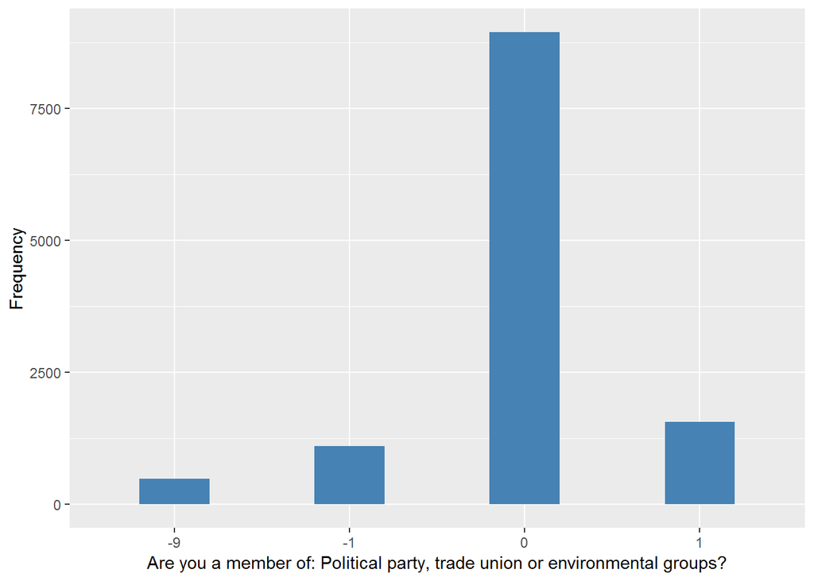

#### 2.1.1.2 Harmonisation algorithm

To compute the harmonize variable from the study-specific variable it has to be recoded as follows:

- `1 into 1, 0 into 0`
- `-1 into 996`
- `-9 into 995`
- `NA into 999`

**R script:**

```r
ELSA_ds_w1 <- tibble(id = ELSA_w1_pol_act$id)
ELSA_ds_w1$pol_act <- car::recode(as.vector(ELSA_w1_pol_act$scorg1), "0='0'; 1='1'; -1='996'; -9='995'; NA='999'")
ELSA_ds_w1$pol_act <- labelled(ELSA_ds_w1$pol_act, labels = c(No = 0, Yes = 1,
    Missing = 999, `Do not know` = 998, Refuse = 997, `Not applicable` = 996,
    `Don't answer` = 995, `Not attempt/not done/not yet recorded` = 994, `Disable to measure` = 993,
    Impute = 992, `CAPI/interviewer error` = 991))
```

#### 2.1.1.3 Statistical description of the new harmonised variable

| Sample size | Missing values |
| --- | --- |
| 12099 | 1593 |

Category

|  | 0 | 1 |
| --- | --- | --- |
| Frequency | 8941.0 | 1565.00 |
| Percentage | 73.9 | 12.93 |

Type of missing

|  | 991 | 992 | 993 | 994 | 995 | 996 | 997 | 998 | 999 | NA |
| --- | --- | --- | --- | --- | --- | --- | --- | --- | --- | --- |
| Frequency | 0 | 0 | 0 | 0 | 485.00 | 1108.00 | 0 | 0 | 0 | 0 |
| Percentage | 0 | 0 | 0 | 0 | 4.01 | 9.16 | 0 | 0 | 0 | 0 |

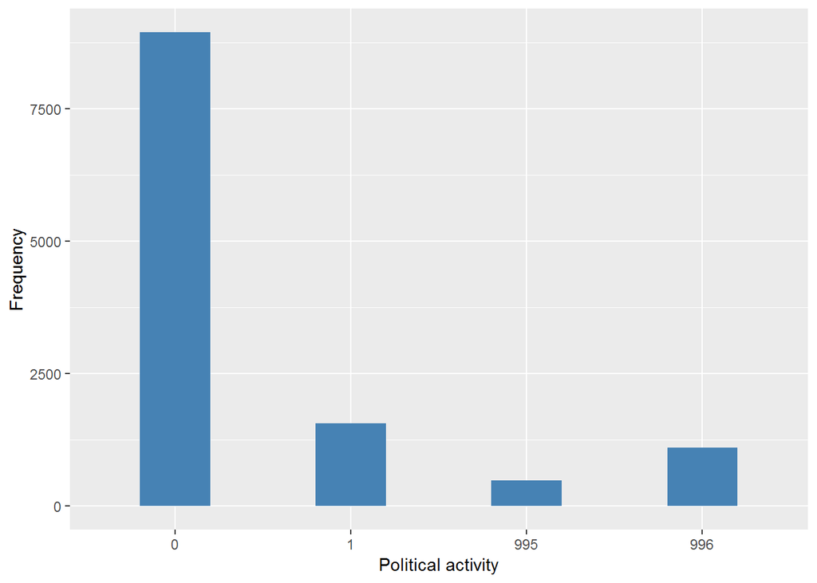

#### 2.1.1.4 Validation

|  | 0 | 1 | -9->995 | -1->996 |
| --- | --- | --- | --- | --- |
| BeforeH | 8941 | 1565 | 485 | 1108 |
| AfterH | 8941 | 1565 | 485 | 1108 |

### 2.1.2 Wave 2

#### 2.1.2.1 Study-specific variable description

The study-specific variable elected to be harmonised is:

- Name: `scorg01`
- Label: `Organisational membership: political party, trade union or environmental group`
- Categories:
  - `0 = No`
  - `1 = Yes`
- Missings:
  - `-9 = Not answered`
  - `-1 = Item not applicable`
- Description:

SCORG01

| Sample size | Missing values |
| --- | --- |
| 9432 | 1666 |

Category

|  | 0 | 1 |
| --- | --- | --- |
| Frequency | 6580.00 | 1186.00 |
| Percentage | 69.76 | 12.57 |

Type of missing

|  | -1 | -9 | NA |
| --- | --- | --- | --- |
| Frequency | 1072.00 | 594.0 | 0 |
| Percentage | 11.37 | 6.3 | 0 |

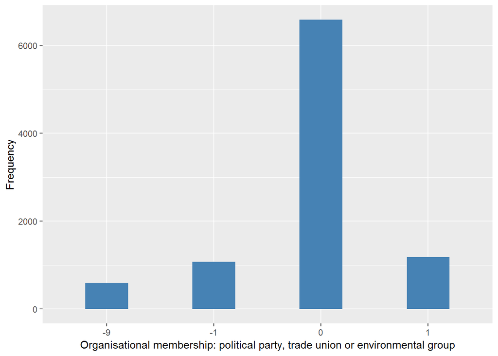

#### 2.1.2.2 Harmonisation algorithm

To compute the harmonize variable from the study-specific variable it has to be recoded as follows:

- `1 into 1, 0 into 0`
- `-1 into 996`
- `-9 into 995`
- `NA into 999`

**R script:**

```r
ELSA_ds_w2 <- tibble(id = ELSA_w2_pol_act$id)
ELSA_ds_w2$pol_act <- car::recode(as.vector(ELSA_w2_pol_act$scorg01), "1='1'; 0='0'; -1='996'; -9='995'; NA='999'")
ELSA_ds_w2$pol_act <- labelled(ELSA_ds_w2$pol_act, labels = c(No = 0, Yes = 1,
    Missing = 999, `Do not know` = 998, Refuse = 997, `Not applicable` = 996,
    `Don't answer` = 995, `Not attempt/not done/not yet recorded` = 994, `Disable to measure` = 993,
    Impute = 992, `CAPI/interviewer error` = 991))
```

#### 2.1.2.3 Statistical description of the new harmonised variable

| Sample size | Missing values |
| --- | --- |
| 9432 | 1666 |

Category

|  | 0 | 1 |
| --- | --- | --- |
| Frequency | 6580.00 | 1186.00 |
| Percentage | 69.76 | 12.57 |

Type of missing

|  | 991 | 992 | 993 | 994 | 995 | 996 | 997 | 998 | 999 | NA |
| --- | --- | --- | --- | --- | --- | --- | --- | --- | --- | --- |
| Frequency | 0 | 0 | 0 | 0 | 594.0 | 1072.00 | 0 | 0 | 0 | 0 |
| Percentage | 0 | 0 | 0 | 0 | 6.3 | 11.37 | 0 | 0 | 0 | 0 |

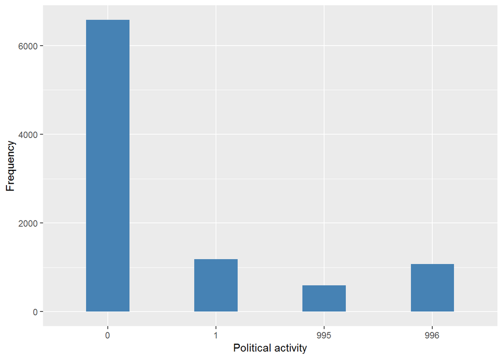

#### 2.1.2.4 Validation

|  | 0 | 1 | -9->995 | -1->996 |
| --- | --- | --- | --- | --- |
| BeforeH | 6580 | 1186 | 594 | 1072 |
| AfterH | 6580 | 1186 | 594 | 1072 |

### 2.1.3 Wave 3

#### 2.1.3.1 Study-specific variable description

The study-specific variable elected to be harmonised is:

- Name: `scorg01`
- Label: `Respondent is a member of a political party, trade union or environmental groups`
- Categories:
  - `0 = No` *not sure whether this is a label for this variable*
  - `1 = Yes`
- Missings:
  - `-9 = Not answered`
  - `-8 = Don't know`
  - `-1 = Item not applicable`
- Description:

SCORG01

| Sample size | Missing values |
| --- | --- |
| 9771 | 2006 |

Category

|  | 0 | 1 |
| --- | --- | --- |
| Frequency | 6636.00 | 1129.00 |
| Percentage | 67.92 | 11.55 |

Type of missing

|  | -1 | -8 | -9 | NA |
| --- | --- | --- | --- | --- |
| Frequency | 1527.00 | 0 | 479.0 | 0 |
| Percentage | 15.63 | 0 | 4.9 | 0 |

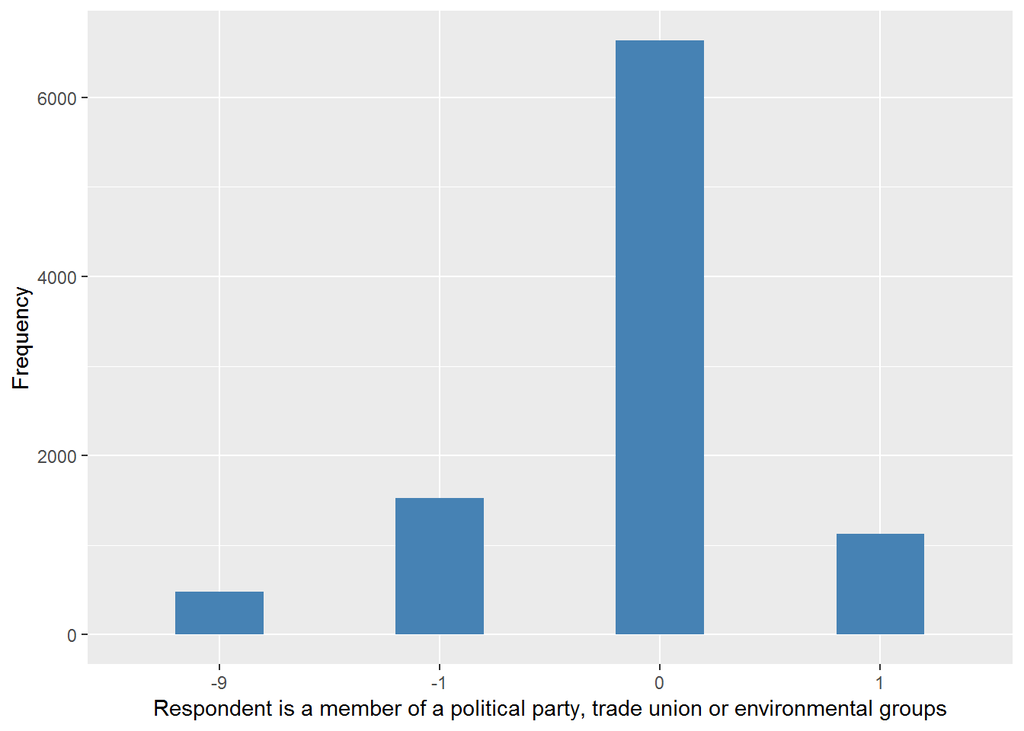

#### 2.1.3.2 Harmonisation algorithm

To compute the harmonize variable from the study-specific variable it has to be recoded as follows:

- `1 into 1, 0 into 0`
- `-1 into 996`
- `-8 into 998`
- `-9 into 995`
- `NA into 999`

**R script:**

```r
ELSA_ds_w3 <- tibble(id = ELSA_w3_pol_act$id)
ELSA_ds_w3$pol_act <- car::recode(as.vector(ELSA_w3_pol_act$scorg01), "1='1'; 0='0'; -1='996'; -8='998'; -9='995'; NA='999'")
ELSA_ds_w3$pol_act <- labelled(ELSA_ds_w3$pol_act, labels = c(No = 0, Yes = 1,
    Missing = 999, `Do not know` = 998, Refuse = 997, `Not applicable` = 996,
    `Don't answer` = 995, `Not attempt/not done/not yet recorded` = 994, `Disable to measure` = 993,
    Impute = 992, `CAPI/interviewer error` = 991))
```

#### 2.1.3.3 Statistical description of the new harmonised variable

| Sample size | Missing values |
| --- | --- |
| 9771 | 2006 |

Category

|  | 0 | 1 |
| --- | --- | --- |
| Frequency | 6636.00 | 1129.00 |
| Percentage | 67.92 | 11.55 |

Type of missing

|  | 991 | 992 | 993 | 994 | 995 | 996 | 997 | 998 | 999 | NA |
| --- | --- | --- | --- | --- | --- | --- | --- | --- | --- | --- |
| Frequency | 0 | 0 | 0 | 0 | 479.0 | 1527.00 | 0 | 0 | 0 | 0 |
| Percentage | 0 | 0 | 0 | 0 | 4.9 | 15.63 | 0 | 0 | 0 | 0 |

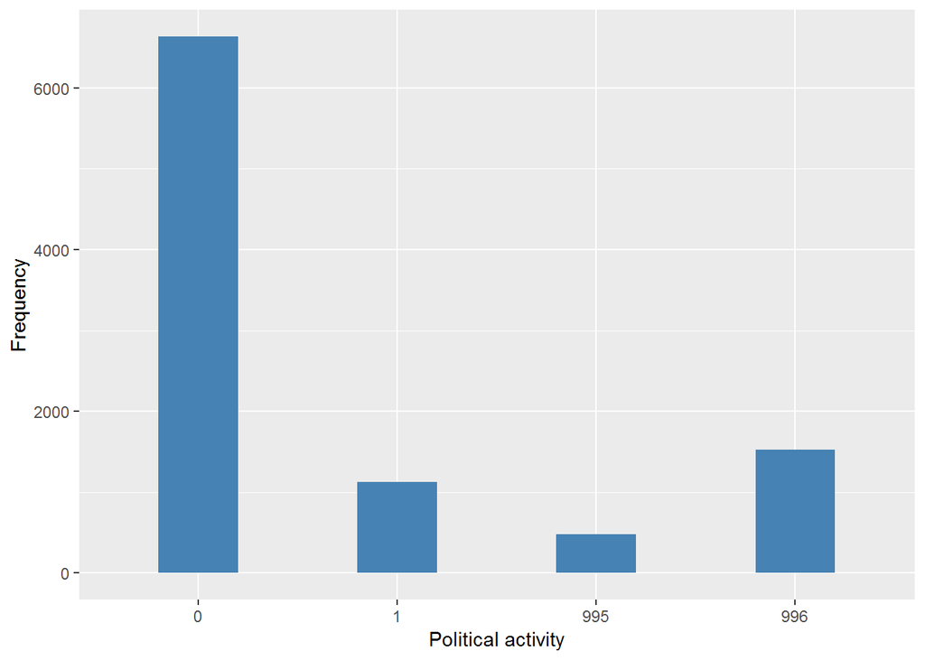

#### 2.1.3.4 Validation

|  | 0 | 1 | -9->995 | -1->996 |
| --- | --- | --- | --- | --- |
| BeforeH | 6636 | 1129 | 479 | 1527 |
| AfterH | 6636 | 1129 | 479 | 1527 |

### 2.1.4 Wave 4

#### 2.1.4.1 Study-specific variable description

The study-specific variable elected to be harmonised is:

- Name: `scorg01`
- Label: `Respondent is a member of a political party, trade union or environmental groups`
- Categories:
  - `0 = No`
  - `1 = Yes`
- Missings:
  - `-9 = Not answered`
  - `-8 = Don't know`
  - `-1 = Not applicable`
- Description:

SCORG01

| Sample size | Missing values |
| --- | --- |
| 11050 | 2170 |

Category

|  | 0 | 1 |
| --- | --- | --- |
| Frequency | 7608.00 | 1272.00 |
| Percentage | 68.85 | 11.51 |

Type of missing

|  | -1 | -8 | -9 | NA |
| --- | --- | --- | --- | --- |
| Frequency | 1708.00 | 0 | 462.00 | 0 |
| Percentage | 15.46 | 0 | 4.18 | 0 |

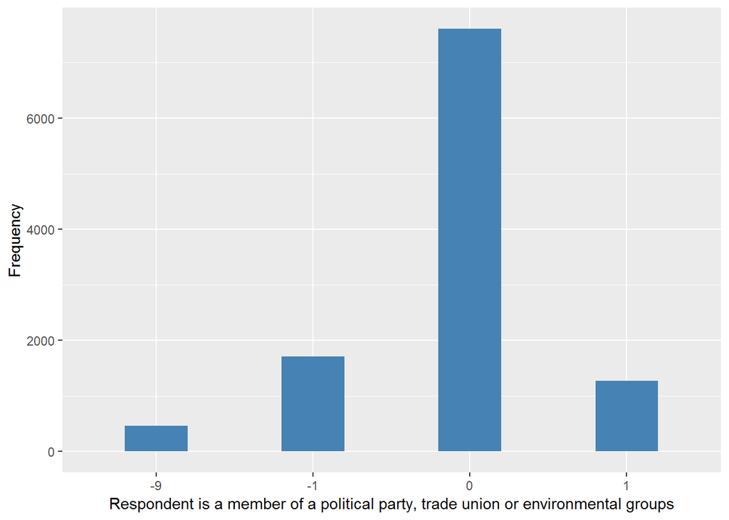

#### 2.1.4.2 Harmonisation algorithm

To compute the harmonize variable from the study-specific variable it has to be recoded as follows:

- `1 into 1, 0 into 0`
- `-1 into 996`
- `-8 into 998`
- `-9 into 995`
- `NA into 999`

**R script:**

```r
ELSA_ds_w4 <- tibble(id = ELSA_w4_pol_act$id)
ELSA_ds_w4$pol_act <- car::recode(as.vector(ELSA_w4_pol_act$scorg01), "1='1'; 0='0'; -1='996'; -8='998'; -9='995'; NA='999'")
ELSA_ds_w4$pol_act <- labelled(ELSA_ds_w4$pol_act, labels = c(No = 0, Yes = 1,
    Missing = 999, `Do not know` = 998, Refuse = 997, `Not applicable` = 996,
    `Don't answer` = 995, `Not attempt/not done/not yet recorded` = 994, `Disable to measure` = 993,
    Impute = 992, `CAPI/interviewer error` = 991))
```

#### 2.1.4.3 Statistical description of the new harmonised variable

| Sample size | Missing values |
| --- | --- |
| 11050 | 2170 |

Category

|  | 0 | 1 |
| --- | --- | --- |
| Frequency | 7608.00 | 1272.00 |
| Percentage | 68.85 | 11.51 |

Type of missing

|  | 991 | 992 | 993 | 994 | 995 | 996 | 997 | 998 | 999 | NA |
| --- | --- | --- | --- | --- | --- | --- | --- | --- | --- | --- |
| Frequency | 0 | 0 | 0 | 0 | 462.00 | 1708.00 | 0 | 0 | 0 | 0 |
| Percentage | 0 | 0 | 0 | 0 | 4.18 | 15.46 | 0 | 0 | 0 | 0 |

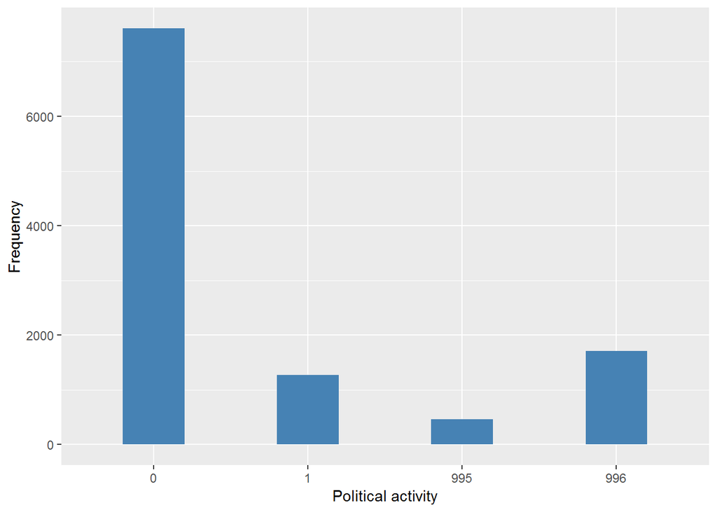

#### 2.1.4.4 Validation

|  | 0 | 1 | -9->995 | -1->996 |
| --- | --- | --- | --- | --- |
| BeforeH | 7608 | 1272 | 462 | 1708 |
| AfterH | 7608 | 1272 | 462 | 1708 |

### 2.1.5 Wave 5

#### 2.1.5.1 Study-specific variable description

The study-specific variable elected to be harmonised is:

- Name: `scorg01`
- Label: `Respondent is a member of a political party, trade union or environmental groups`
- Categories:
  - `0 = No`
  - `1 = Yes`
- Missings:
  - `-9 = Not answered`
  - `-8 = Don't know`
  - `-2 = Schedule Not Applicable`
  - `-1 = Item not applicable`
- Description:

SCORG01

| Sample size | Missing values |
| --- | --- |
| 10274 | 1729 |

Category

|  | 0 | 1 |
| --- | --- | --- |
| Frequency | 7374.00 | 1171.0 |
| Percentage | 71.77 | 11.4 |

Type of missing

|  | -1 | -2 | -8 | -9 | NA |
| --- | --- | --- | --- | --- | --- |
| Frequency | 0 | 1244.00 | 0 | 485.00 | 0 |
| Percentage | 0 | 12.11 | 0 | 4.72 | 0 |

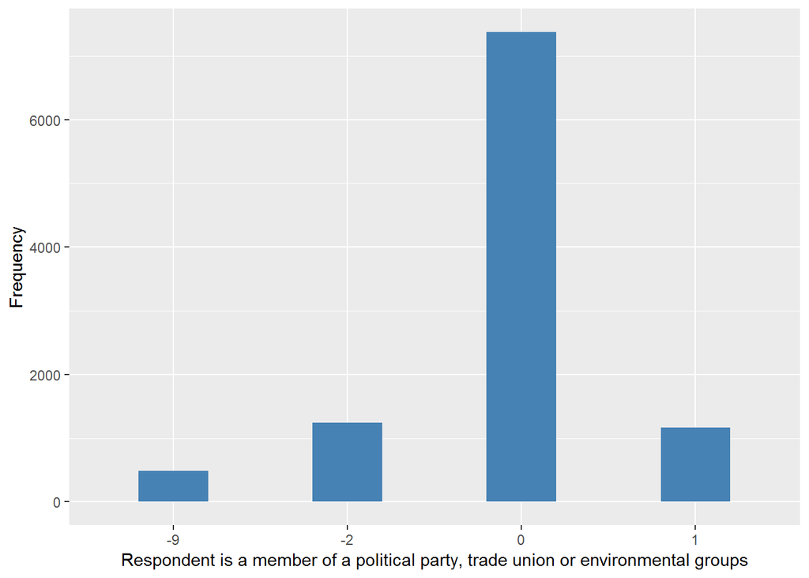

#### 2.1.5.2 Harmonisation algorithm

To compute the harmonize variable from the study-specific variable it has to be recoded as follows:

- `1 into 1, 0 into 0`
- `-1 or -2 into 996`
- `-8 into 998`
- `-9 into 995`
- `NA into 999`

**R script:**

```r
ELSA_ds_w5 <- tibble(id = ELSA_w5_pol_act$id)
ELSA_ds_w5$pol_act <- car::recode(as.vector(ELSA_w5_pol_act$scorg01), "1='1'; 0='0'; -1='996'; -2='996'; -8='998'; -9='995'; NA='999'")
ELSA_ds_w5$pol_act <- labelled(ELSA_ds_w5$pol_act, labels = c(No = 0, Yes = 1,
    Missing = 999, `Do not know` = 998, Refuse = 997, `Not applicable` = 996,
    `Don't answer` = 995, `Not attempt/not done/not yet recorded` = 994, `Disable to measure` = 993,
    Impute = 992, `CAPI/interviewer error` = 991))
```

#### 2.1.5.3 Statistical description of the new harmonised variable

| Sample size | Missing values |
| --- | --- |
| 10274 | 1729 |

Category

|  | 0 | 1 |
| --- | --- | --- |
| Frequency | 7374.00 | 1171.0 |
| Percentage | 71.77 | 11.4 |

Type of missing

|  | 991 | 992 | 993 | 994 | 995 | 996 | 997 | 998 | 999 | NA |
| --- | --- | --- | --- | --- | --- | --- | --- | --- | --- | --- |
| Frequency | 0 | 0 | 0 | 0 | 485.00 | 1244.00 | 0 | 0 | 0 | 0 |
| Percentage | 0 | 0 | 0 | 0 | 4.72 | 12.11 | 0 | 0 | 0 | 0 |

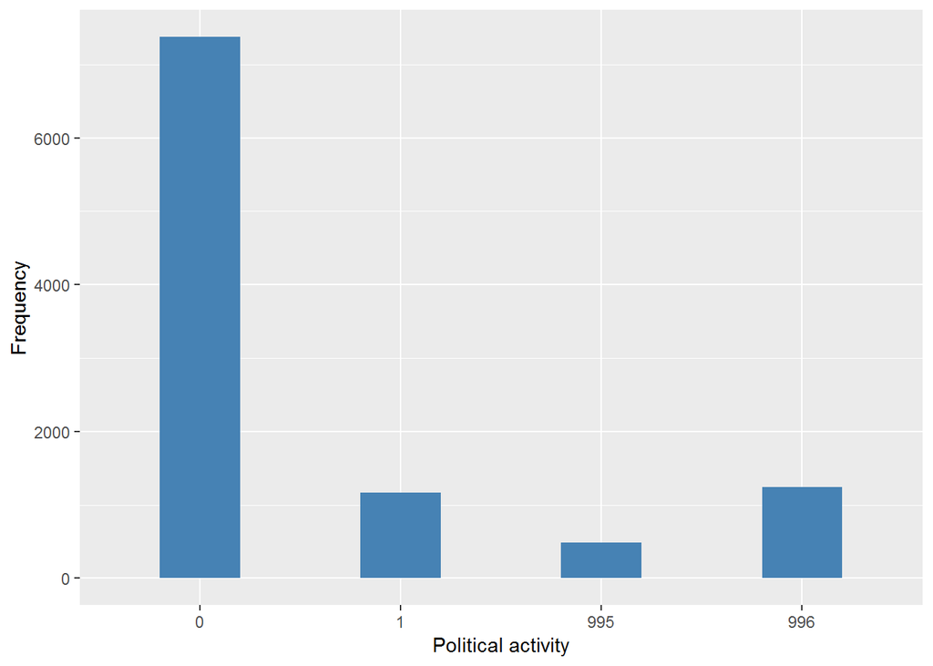

#### 2.1.5.4 Validation

|  | 0 | 1 | -9->995 | -2->996 |
| --- | --- | --- | --- | --- |
| BeforeH | 7374 | 1171 | 485 | 1244 |
| AfterH | 7374 | 1171 | 485 | 1244 |

### 2.1.6 Wave 6

#### 2.1.6.1 Study-specific variable description

The study-specific variable elected to be harmonised is:

- Name: `scorg01`
- Label: `Respondent is a member of a political party, trade union or environmental groups`
- Categories:
  - `0 = No`
  - `1 = Yes`
- Missings:
  - `-9 = Not answered`
  - `-8 = Don't know`
  - `-2 = Schedule Not Applicable`
  - `-1 = Item not applicable`
- Description:

SCORG01

| Sample size | Missing values |
| --- | --- |
| 10601 | 2026 |

Category

|  | 0 | 1 |
| --- | --- | --- |
| Frequency | 7395.00 | 1180.00 |
| Percentage | 69.76 | 11.13 |

Type of missing

|  | -1 | -2 | -8 | -9 | NA |
| --- | --- | --- | --- | --- | --- |
| Frequency | 0 | 1604.00 | 0 | 422.00 | 0 |
| Percentage | 0 | 15.13 | 0 | 3.98 | 0 |

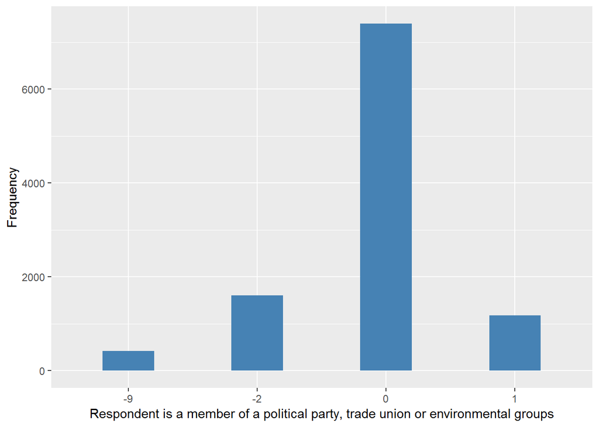

#### 2.1.6.2 Harmonisation algorithm

To compute the harmonize variable from the study-specific variable it has to be recoded as follows:

- `1 into 1, 0 into 0`
- `-1 or -2 into 996`
- `-8 into 998`
- `-9 into 995`
- `NA into 999`

**R script:**

```r
ELSA_ds_w6 <- tibble(id = ELSA_w6_pol_act$id)
ELSA_ds_w6$pol_act <- car::recode(as.vector(ELSA_w6_pol_act$scorg01), "1='1'; 0='0'; -1='996'; -2='996'; -8='998'; -9='995'; NA='999'")
ELSA_ds_w6$pol_act <- labelled(ELSA_ds_w6$pol_act, labels = c(No = 0, Yes = 1,
    Missing = 999, `Do not know` = 998, Refuse = 997, `Not applicable` = 996,
    `Don't answer` = 995, `Not attempt/not done/not yet recorded` = 994, `Disable to measure` = 993,
    Impute = 992, `CAPI/interviewer error` = 991))
```

#### 2.1.6.3 Statistical description of the new harmonised variable

| Sample size | Missing values |
| --- | --- |
| 10601 | 2026 |

Category

|  | 0 | 1 |
| --- | --- | --- |
| Frequency | 7395.00 | 1180.00 |
| Percentage | 69.76 | 11.13 |

Type of missing

|  | 991 | 992 | 993 | 994 | 995 | 996 | 997 | 998 | 999 | NA |
| --- | --- | --- | --- | --- | --- | --- | --- | --- | --- | --- |
| Frequency | 0 | 0 | 0 | 0 | 422.00 | 1604.00 | 0 | 0 | 0 | 0 |
| Percentage | 0 | 0 | 0 | 0 | 3.98 | 15.13 | 0 | 0 | 0 | 0 |

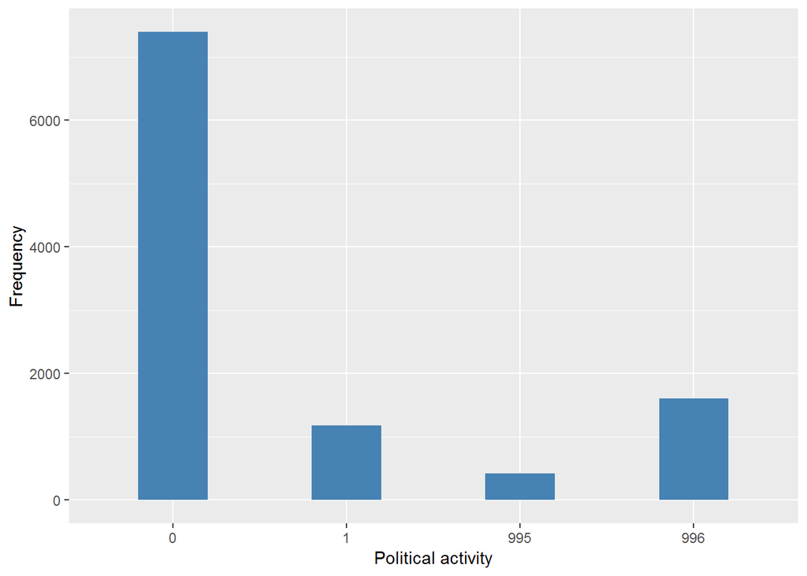

#### 2.1.6.4 Validation

|  | 0 | 1 | -9->995 | -2->996 |
| --- | --- | --- | --- | --- |
| BeforeH | 7395 | 1180 | 422 | 1604 |
| AfterH | 7395 | 1180 | 422 | 1604 |

### 2.1.7 Wave 7

#### 2.1.7.1 Study-specific variable description

The study-specific variable elected to be harmonised is:

- Name: `scorg01`
- Label: `Respondent is a member of a political party, trade union or environmental groups`
- Categories:
  - `0 = No`
  - `1 = Yes`
- Missings:
  - `-9 = Not answered`
  - `-8 = Don't know`
  - `-2 = Schedule Not Applicable`
  - `-1 = Item not applicable`
- Description:

| Sample size | Missing values |
| --- | --- |
| 9666 | 1863 |

Category

|  | 0 | 1 |
| --- | --- | --- |
| Frequency | 6791.00 | 1012.00 |
| Percentage | 70.26 | 10.47 |

Type of missing

|  | -1 | -2 | -8 | -9 | NA |
| --- | --- | --- | --- | --- | --- |
| Frequency | 0 | 1469.0 | 0 | 394.00 | 0 |
| Percentage | 0 | 15.2 | 0 | 4.08 | 0 |

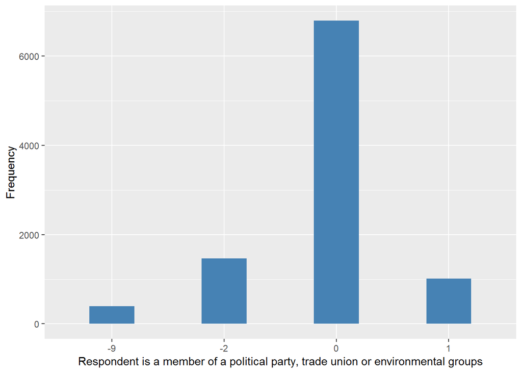

#### 2.1.7.2 Harmonisation algorithm

To compute the harmonize variable from the study-specific variable it has to be recoded as follows:

- `1 into 1, 0 into 0`
- `-1 or -2 into 996`
- `-8 into 998`
- `-9 into 995`
- `NA into 999`

**R script:**

```r
ELSA_ds_w7 <- tibble(id = ELSA_w7_pol_act$id)
ELSA_ds_w7$pol_act <- car::recode(as.vector(ELSA_w7_pol_act$scorg01), "1='1'; 0='0'; -1='996'; -2='996'; -8='998'; -9='995'; NA='999'")
ELSA_ds_w7$pol_act <- labelled(ELSA_ds_w7$pol_act, labels = c(No = 0, Yes = 1,
    Missing = 999, `Do not know` = 998, Refuse = 997, `Not applicable` = 996,
    `Don't answer` = 995, `Not attempt/not done/not yet recorded` = 994, `Disable to measure` = 993,
    Impute = 992, `CAPI/interviewer error` = 991))
```

#### 2.1.7.3 Statistical description of the new harmonised variable

| Sample size | Missing values |
| --- | --- |
| 9666 | 1863 |

Category

|  | 0 | 1 |
| --- | --- | --- |
| Frequency | 6791.00 | 1012.00 |
| Percentage | 70.26 | 10.47 |

Type of missing

|  | 991 | 992 | 993 | 994 | 995 | 996 | 997 | 998 | 999 | NA |
| --- | --- | --- | --- | --- | --- | --- | --- | --- | --- | --- |
| Frequency | 0 | 0 | 0 | 0 | 394.00 | 1469.0 | 0 | 0 | 0 | 0 |
| Percentage | 0 | 0 | 0 | 0 | 4.08 | 15.2 | 0 | 0 | 0 | 0 |

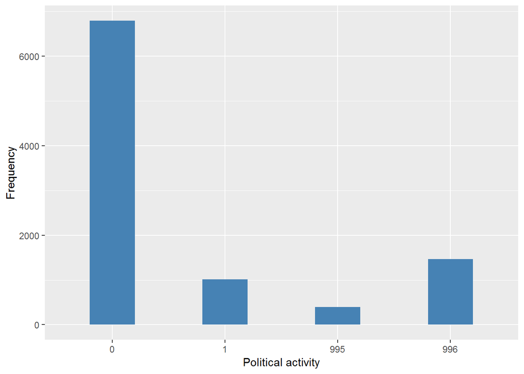

#### 2.1.7.4 Validation

|  | 0 | 1 | -9->995 | -2->996 |
| --- | --- | --- | --- | --- |
| BeforeH | 6791 | 1012 | 394 | 1469 |
| AfterH | 6791 | 1012 | 394 | 1469 |

# 3 Quality estimation